# 4. Astrocyte cluster analysis

Cankun Wang, Faith Brennan

02/08/2022

```r
this_ct <- 4
this_obj <- subset(combine.combined, idents = this_ct)
DefaultAssay(this_obj) <- "RNA"
this_obj <- NormalizeData(this_obj)
this_obj <- FindVariableFeatures(this_obj)
this_obj <- ScaleData(this_obj)
this_obj <- RunPCA(this_obj, verbose = FALSE)
this_obj <- FindNeighbors(this_obj, dims = 1:5)
this_obj <- FindClusters(this_obj, resolution = 0.1)
this_obj <- RunUMAP(this_obj, reduction = "pca", dims = 1:5)
Save(combine.combined, "combined.RData")
Save(this_obj, "this_astro_obj.RData")
Idents(this_obj) <- this_obj$seurat_clusters
Save(combine.combined, "combined.RData")
Save(this_obj, "this_astro_obj.RData")
```

# 1 Check top DEGs in each cluster to assist with cluster description

```r
clusterzero.de.markers <- FindMarkers(this_obj, ident.1 = "0", ident.2 = NULL, only.pos = TRUE)
clusterone.de.markers <- FindMarkers(this_obj, ident.1 = "1", ident.2 = NULL, only.pos = TRUE)
clustertwo.de.markers <- FindMarkers(this_obj, ident.1 = "2", ident.2 = NULL, only.pos = TRUE)

#Use “head(clusterID.de.markers, n=50)” to preview de.markers for each astrocyte cluster.
#Export full de.marker list for each cluster
write.csv(clusterzero.de.markers, "0.de.markers")
write.csv(clusterone.de.markers, "1.de.markers")
write.csv(clustertwo.de.markers, "2.de.markers")
#.csv files are combined into the excel file “Astrocyte clusters”

subcluster.averages <- AverageExpression(this_obj, assays = "RNA", "subcluster.averages")
write.csv(subcluster.averages, "Astrocyte subcluster gene avgs")

#Data is in the far right tab of the excel file “Astrocyte clusters”
```

# 2 Rename clusters

```r
Idents(this_obj) <- this_obj$seurat_clusters
this_obj <- RenameIdents(this_obj, `0` = "Transporter")
this_obj <- RenameIdents(this_obj, `1` = "Metabolism")
this_obj <- RenameIdents(this_obj, `2` = "Inflammation")
```

# 3 Plot all cells

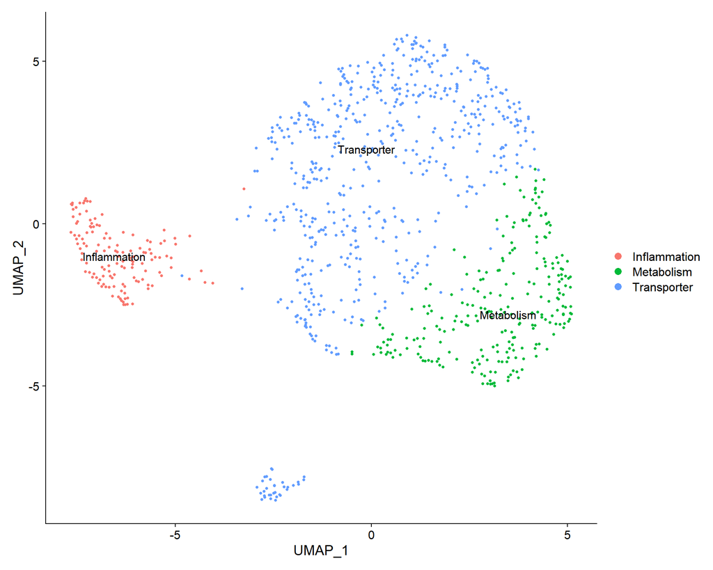

```r
DimPlot(this_obj, label = TRUE)
```

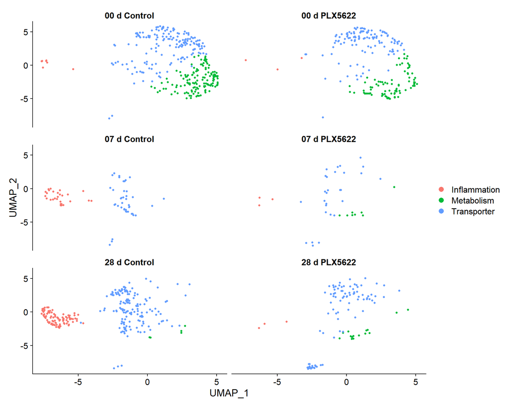

```r
DimPlot(this_obj, reduction = "umap", split.by = "orig.ident", ncol = 2)
```

# 4 Create a DotPlot showing five of the de.markers for each cluster

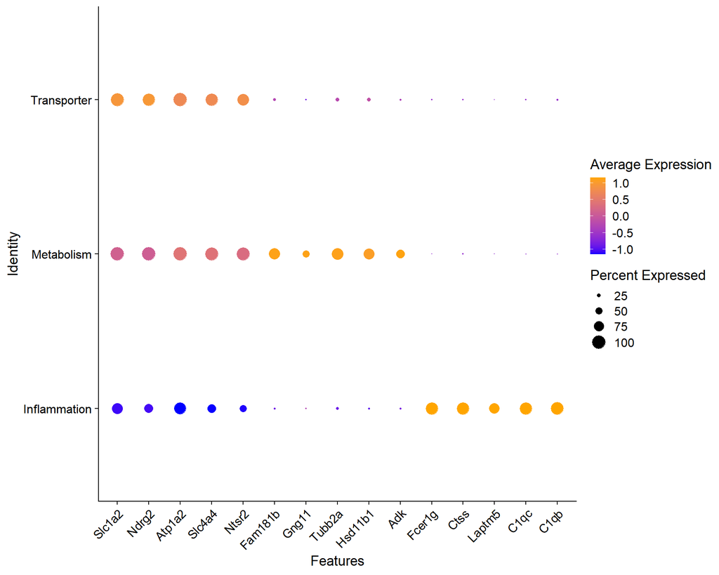

```r
markers.to.plot <- c("C1qb", "C1qc", "Laptm5", "Ctss", "Fcer1g", "Adk", "Hsd11b1", "Tubb2a", "Gng11", "Fam181b", "Ntsr2", "Slc4a4", "Atp1a2", "Ndrg2", "Slc1a2")
DotPlot(this_obj, features = rev(markers.to.plot), assay = "RNA", cols = c("blue", "orange"), dot.scale = 6) + RotatedAxis()
```

# 5 Show Astrocyte cluster data

```r
Astrocyte_cluster_cell_number <- (table(Idents(this_obj)))
#write.csv(Astrocyte_cluster_cell_number, "Astrocyte cluster cell number")
Astrocyte_cluster_cell_number
```

```
##
## Inflammation   Metabolism  Transporter
##          135          250          589
```

```r
Astrocyte_cell_number_by_group<- table(Idents(this_obj), this_obj$orig.ident)
#write.csv(Astrocyte_cell_number_by_group, "Astrocyte_cluster no._by group")
Astrocyte_cell_number_by_group
```

```
##
##                00 d Control 00 d PLX5622 07 d Control 07 d PLX5622 28 d Control
##   Inflammation            9            3           28            3           89
##   Metabolism            137           85            0            8            5
##   Transporter           164          116           41           28          151
##
##                28 d PLX5622
##   Inflammation            3
##   Metabolism             15
##   Transporter            89
```

```r
Astrocyte_cell_percent <- (prop.table(table(Idents(this_obj), this_obj$orig.ident), margin = 2))
#write.csv(Astrocyte_cell_percent, "Astrocyte cell percentages")
Astrocyte_cell_percent
```

```
##
##                00 d Control 00 d PLX5622 07 d Control 07 d PLX5622 28 d Control
##   Inflammation   0.02903226   0.01470588   0.40579710   0.07692308   0.36326531
##   Metabolism     0.44193548   0.41666667   0.00000000   0.20512821   0.02040816
##   Transporter    0.52903226   0.56862745   0.59420290   0.71794872   0.61632653
##
##                28 d PLX5622
##   Inflammation   0.02803738
##   Metabolism     0.14018692
##   Transporter    0.83177570
```

```r
#Files are combined into the file excel  “Astrocyte cell numbers” and data is shown in Fig. 7D, E
```

# 6 Violin plots for Fig. 7J-L

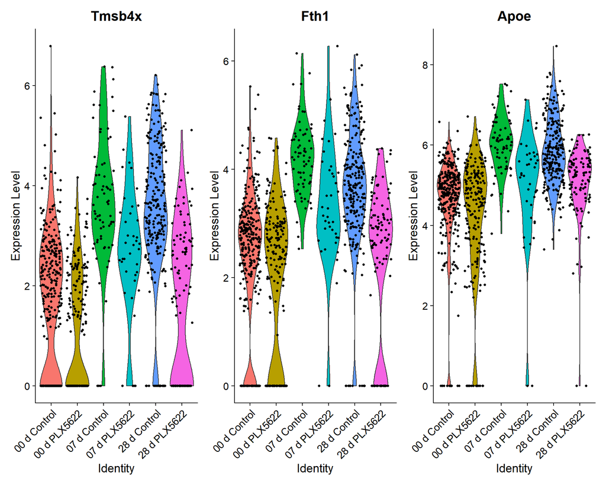

```r
VlnPlot(combine.combined, features = c("Tmsb4x", "Fth1", "Apoe"), idents = "4", group.by = "orig.ident", pt.size = 1, assay = "RNA")
```

# 7 Statistical analysis for Fig. 7J-L

```r
FindMarkers(
  this_obj,
  ident.1 = "Group 1",
  ident.2 = "Group 2",
  group.by = "orig.ident",
  features = c("gene name"),
  logfc.threshold = 0.001,
  test.use = "wilcox"
)
```

# 8 Analysis for Volcano plot for Fig. 7F and heatmap in Fig. 7I

```r
Astrocyte_28dvs0d <- FindMarkers(object = combine.combined, ident.1 = WhichCells(combine.combined, cells = rownames(combine.combined@meta.data[combine.combined@meta.data$orig.ident=="28 d Control",]), idents = "4"),ident.2 = WhichCells(combine.combined, cells = rownames(combine.combined@meta.data[combine.combined@meta.data$orig.ident=="00 d Control",]), idents = "4"), min.pct = 0.1, logfc.threshold = 0.176, assay = "RNA", only.pos = FALSE)
write.csv(Astrocyte_28dvs0d, "Astrocyte 28d vs 0d")

Astrocyte_28dplxvs28dveh <- FindMarkers(object = combine.combined, ident.1 = WhichCells(combine.combined, cells = rownames(combine.combined@meta.data[combine.combined@meta.data$orig.ident=="28 d PLX5622",]), idents = "4"),ident.2 = WhichCells(combine.combined, cells = rownames(combine.combined@meta.data[combine.combined@meta.data$orig.ident=="28 d Control",]), idents = "4"), min.pct = 0.1, logfc.threshold = 0.176, assay = "RNA", only.pos = FALSE)
write.csv(Astrocyte_28dplxvs28dveh, "Astrocyte 28dplx vs 28dveh")
```

# 9 Introduction of bootstrap

We use the “boot” R package to perform bootstrap analysis.

The R package boot allows a user to easily generate bootstrap samples (10000) of any statistic that they can calculate in R.

We perform bootstrap analysis for the mixture of cell types from six samples.

Four outputs will be generated including:

- Variance of bootstrap resamples (needed by bootstrap using bca bootstrap method). Smaller variance indicates better consistency among the resamples.
- 95% Confidence Intervals (CIs) used to test the statistical confidence of the bootstrap results. 95% probability can be ensured that the estimated statistic falls within the CI. CIs are calculated by normal approximation (norm), basic bootstrap (basic), bootstrap percentile (perc), and bootstrap percentile (bca).
- Histogram including a dotted vertical line, which indicates the location of the original statistic.
- Quantile-quantile (q-q) plot, a graphical technique for determining if two data sets come from populations with a common distribution. The x-axis represents the standard normal distribution, while the y-axis denotes the distribution of the resamples.

# 10 Cell subtype percentages of Control 00d

## 10.1 Bootstrap of the percentage of Transporter cells

Summary of the bootstrap resamples:

|  | R | original | bootBias | bootSE | bootMed |
| --- | --- | --- | --- | --- | --- |
| 1 | 10000 | 0.5290323 | 0.0002673985 | 0.02856222 | 0.529052 |

The variance of the percentage of Transporter cells in the bootstrap resamples is 8.158005110^{-4}.

The confidence interval of the percentage of Transporter cells in the bootstrap resamples is presented as follows.

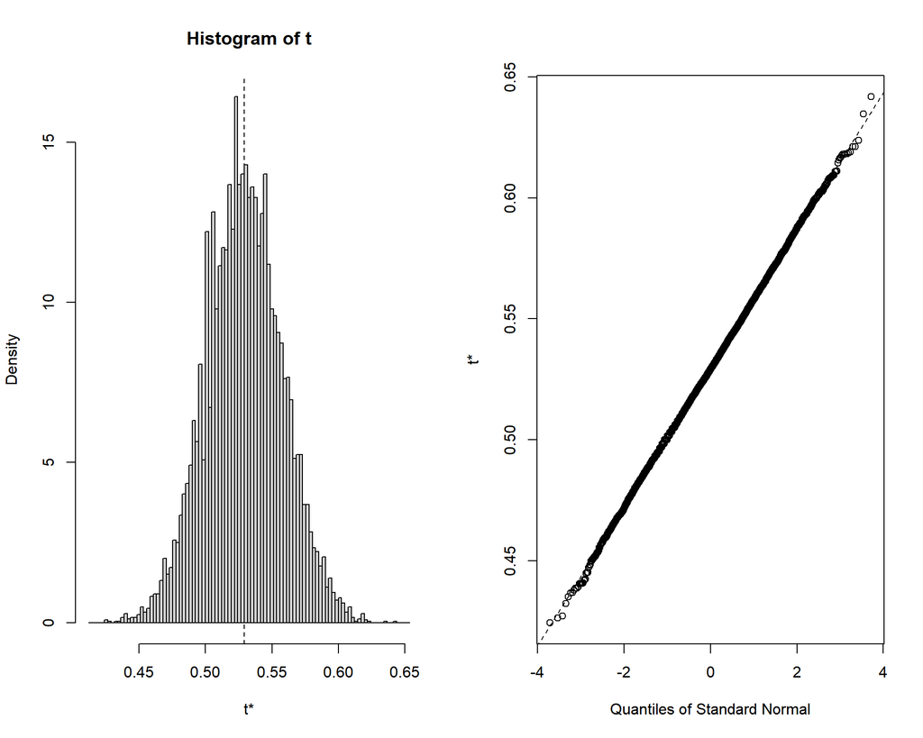

```
## BOOTSTRAP CONFIDENCE INTERVAL CALCULATIONS
## Based on 10000 bootstrap replicates
##
## CALL :
## boot.ci(boot.out = bootcorr, type = c("norm", "basic", "perc",
##     "bca"))
##
## Intervals :
## Level      Normal              Basic
## 95%   ( 0.4728,  0.5847 )   ( 0.4720,  0.5849 )
##
## Level     Percentile            BCa
## 95%   ( 0.4732,  0.5861 )   ( 0.4727,  0.5858 )
## Calculations and Intervals on Original Scale
```

## 10.2 Bootstrap of the percentage of Metabolism cells

Summary of the bootstrap resamples:

|  | R | original | bootBias | bootSE | bootMed |
| --- | --- | --- | --- | --- | --- |
| 1 | 10000 | 0.4419355 | -0.0002750559 | 0.02840782 | 0.4418934 |

The variance of the percentage of Metabolism cells in the bootstrap resamples is 8.070041210^{-4}.

The confidence interval of the percentage of Metabolism cells in the bootstrap resamples is presented as follows.

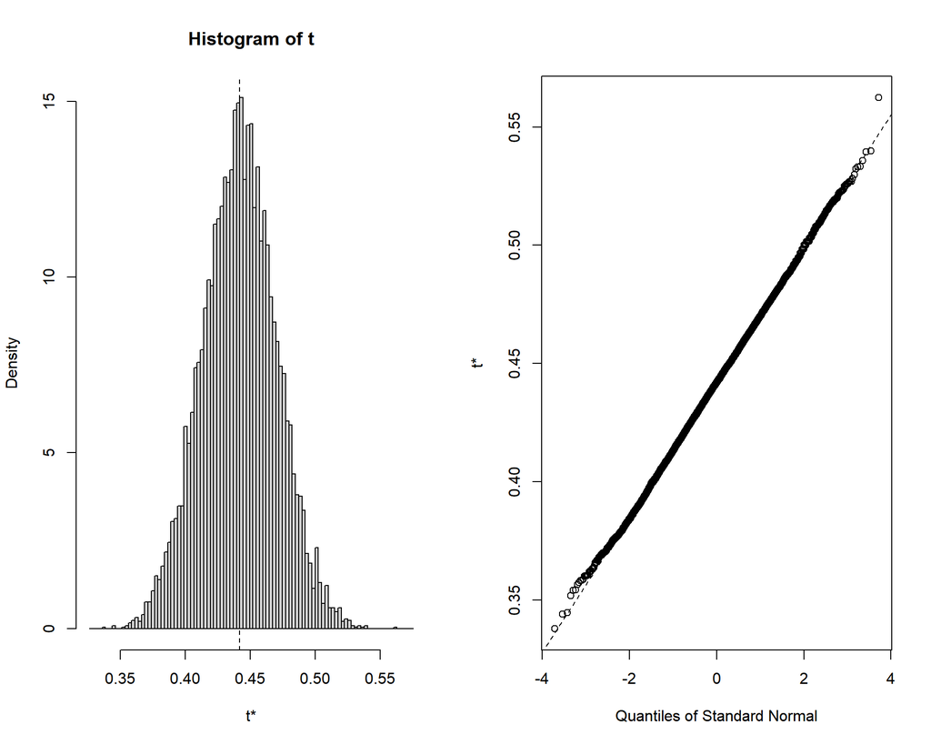

```
## BOOTSTRAP CONFIDENCE INTERVAL CALCULATIONS
## Based on 10000 bootstrap replicates
##
## CALL :
## boot.ci(boot.out = bootcorr, type = c("norm", "basic", "perc",
##     "bca"))
##
## Intervals :
## Level      Normal              Basic
## 95%   ( 0.3865,  0.4979 )   ( 0.3856,  0.4987 )
##
## Level     Percentile            BCa
## 95%   ( 0.3852,  0.4983 )   ( 0.3856,  0.4983 )
## Calculations and Intervals on Original Scale
```

## 10.3 Bootstrap of the percentage of Inflammation cells

Summary of the bootstrap resamples:

|  | R | original | bootBias | bootSE | bootMed |
| --- | --- | --- | --- | --- | --- |
| 1 | 10000 | 0.02903226 | 7.657399e-06 | 0.009497972 | 0.02848101 |

The variance of the percentage of Inflammation cells in the bootstrap resamples is 9.021147510^{-5}.

The confidence interval of the percentage of Inflammation cells in the bootstrap resamples is presented as follows.

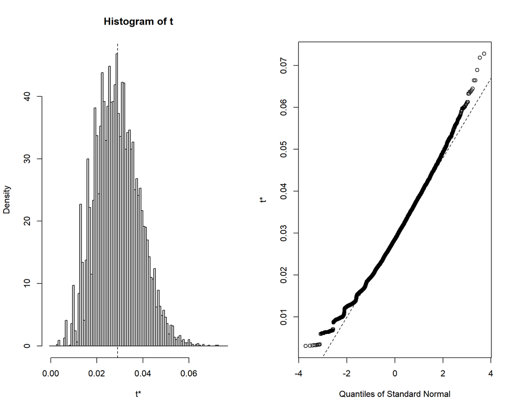

```
## BOOTSTRAP CONFIDENCE INTERVAL CALCULATIONS
## Based on 10000 bootstrap replicates
##
## CALL :
## boot.ci(boot.out = bootcorr, type = c("norm", "basic", "perc",
##     "bca"))
##
## Intervals :
## Level      Normal              Basic
## 95%   ( 0.0104,  0.0476 )   ( 0.0092,  0.0454 )
##
## Level     Percentile            BCa
## 95%   ( 0.0126,  0.0489 )   ( 0.0135,  0.0528 )
## Calculations and Intervals on Original Scale
```

# 11 Cell subtype percentages of Control 07d

## 11.1 Bootstrap of the percentage of Transporter cells

Summary of the bootstrap resamples:

|  | R | original | bootBias | bootSE | bootMed |
| --- | --- | --- | --- | --- | --- |
| 1 | 10000 | 0.5942029 | 0.001081694 | 0.05965112 | 0.5949367 |

The variance of the percentage of Transporter cells in the bootstrap resamples is 0.0035583.

The confidence interval of the percentage of Transporter cells in the bootstrap resamples is presented as follows.

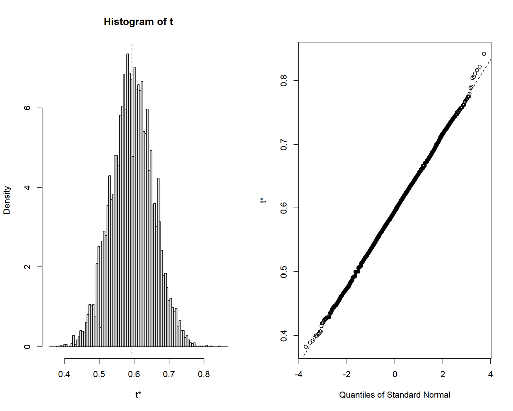

```
## BOOTSTRAP CONFIDENCE INTERVAL CALCULATIONS
## Based on 10000 bootstrap replicates
##
## CALL :
## boot.ci(boot.out = bootcorr, type = c("norm", "basic", "perc",
##     "bca"))
##
## Intervals :
## Level      Normal              Basic
## 95%   ( 0.4762,  0.7100 )   ( 0.4741,  0.7122 )
##
## Level     Percentile            BCa
## 95%   ( 0.4762,  0.7143 )   ( 0.4722,  0.7097 )
## Calculations and Intervals on Original Scale
```

## 11.2 Bootstrap of the percentage of Metabolism cells

There is no Metabolism cells in this treatment condition.

## 11.3 Bootstrap of the percentage of Inflammation cells

Summary of the bootstrap resamples:

|  | R | original | bootBias | bootSE | bootMed |
| --- | --- | --- | --- | --- | --- |
| 1 | 10000 | 0.4057971 | -0.001081694 | 0.05965112 | 0.4050633 |

The variance of the percentage of Inflammation cells in the bootstrap resamples is 0.0035583.

The confidence interval of the percentage of Inflammation cells in the bootstrap resamples is presented as follows.

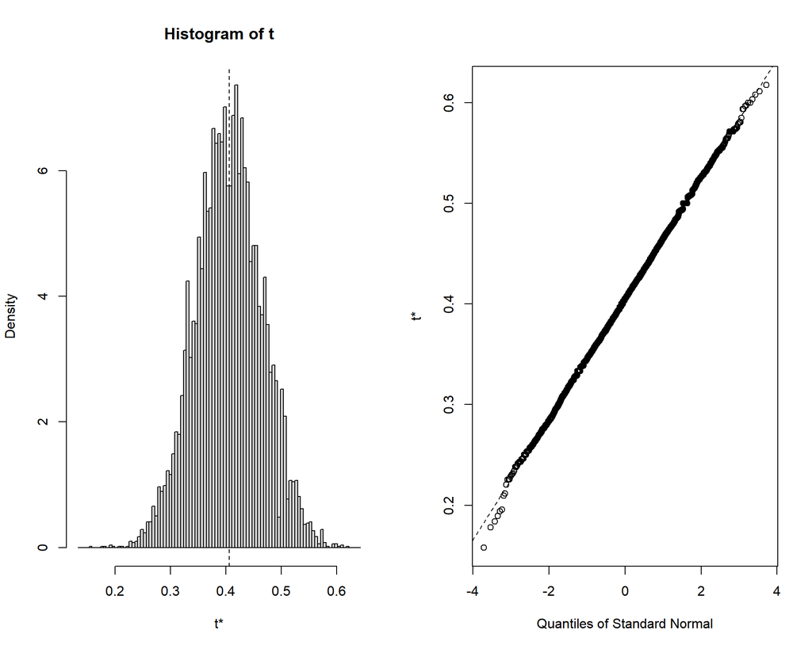

```
## BOOTSTRAP CONFIDENCE INTERVAL CALCULATIONS
## Based on 10000 bootstrap replicates
##
## CALL :
## boot.ci(boot.out = bootcorr, type = c("norm", "basic", "perc",
##     "bca"))
##
## Intervals :
## Level      Normal              Basic
## 95%   ( 0.2900,  0.5238 )   ( 0.2878,  0.5259 )
##
## Level     Percentile            BCa
## 95%   ( 0.2857,  0.5238 )   ( 0.2881,  0.5263 )
## Calculations and Intervals on Original Scale
```

# 12 Cell subtype percentages of Control 28d

## 12.1 Bootstrap of the percentage of Transporter cells

Summary of the bootstrap resamples:

|  | R | original | bootBias | bootSE | bootMed |
| --- | --- | --- | --- | --- | --- |
| 1 | 10000 | 0.6163265 | 0.0001501068 | 0.03139949 | 0.6166667 |

The variance of the percentage of Transporter cells in the bootstrap resamples is 9.859281710^{-4}.

The confidence interval of the percentage of Transporter cells in the bootstrap resamples is presented as follows.

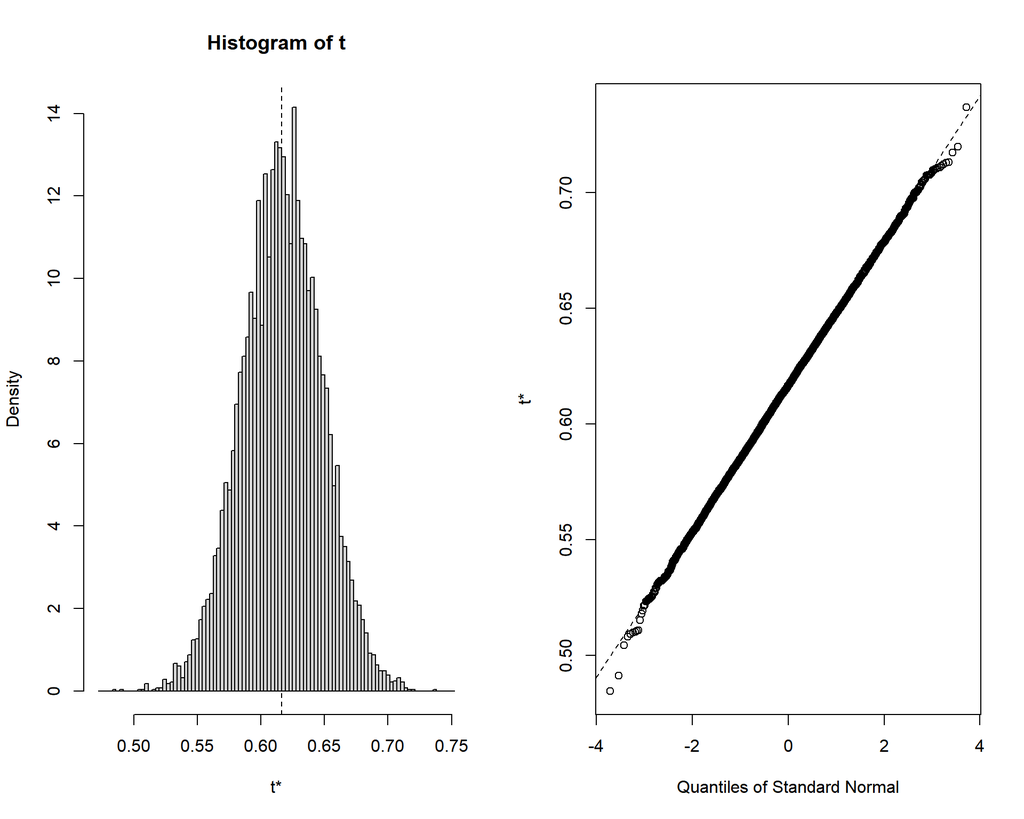

```
## BOOTSTRAP CONFIDENCE INTERVAL CALCULATIONS
## Based on 10000 bootstrap replicates
##
## CALL :
## boot.ci(boot.out = bootcorr, type = c("norm", "basic", "perc",
##     "bca"))
##
## Intervals :
## Level      Normal              Basic
## 95%   ( 0.5546,  0.6777 )   ( 0.5548,  0.6784 )
##
## Level     Percentile            BCa
## 95%   ( 0.5542,  0.6778 )   ( 0.5529,  0.6762 )
## Calculations and Intervals on Original Scale
```

## 12.2 Bootstrap of the percentage of Metabolism cells

Summary of the bootstrap resamples:

|  | R | original | bootBias | bootSE | bootMed |
| --- | --- | --- | --- | --- | --- |
| 1 | 10000 | 0.02040816 | -8.496173e-05 | 0.009042759 | 0.01996016 |

The variance of the percentage of Metabolism cells in the bootstrap resamples is 8.177148510^{-5}.

The confidence interval of the percentage of Metabolism cells in the bootstrap resamples is presented as follows.

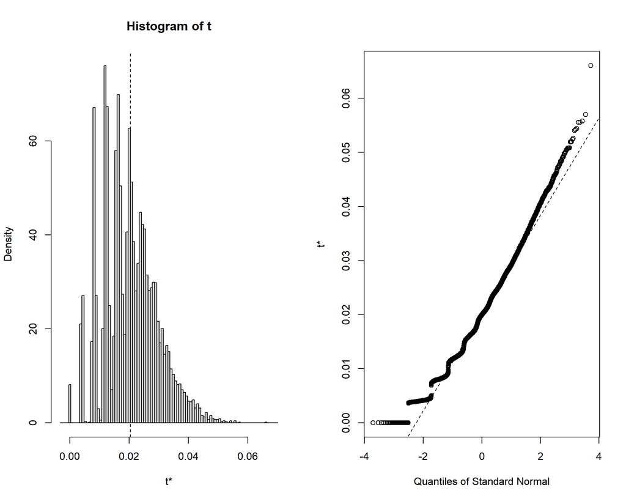

```
## BOOTSTRAP CONFIDENCE INTERVAL CALCULATIONS
## Based on 10000 bootstrap replicates
##
## CALL :
## boot.ci(boot.out = bootcorr, type = c("norm", "basic", "perc",
##     "bca"))
##
## Intervals :
## Level      Normal              Basic
## 95%   ( 0.0028,  0.0382 )   ( 0.0008,  0.0367 )
##
## Level     Percentile            BCa
## 95%   ( 0.0041,  0.0400 )   ( 0.0078,  0.0451 )
## Calculations and Intervals on Original Scale
```

## 12.3 Bootstrap of the percentage of Inflammation cells

Summary of the bootstrap resamples:

|  | R | original | bootBias | bootSE | bootMed |
| --- | --- | --- | --- | --- | --- |
| 1 | 10000 | 0.3632653 | -6.514502e-05 | 0.03107673 | 0.3632287 |

The variance of the percentage of Inflammation cells in the bootstrap resamples is 9.657632210^{-4}.

The confidence interval of the percentage of Inflammation cells in the bootstrap resamples is presented as follows.

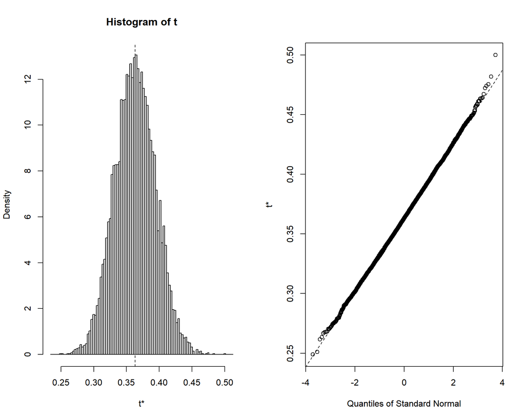

```
## BOOTSTRAP CONFIDENCE INTERVAL CALCULATIONS
## Based on 10000 bootstrap replicates
##
## CALL :
## boot.ci(boot.out = bootcorr, type = c("norm", "basic", "perc",
##     "bca"))
##
## Intervals :
## Level      Normal              Basic
## 95%   ( 0.3024,  0.4242 )   ( 0.3022,  0.4240 )
##
## Level     Percentile            BCa
## 95%   ( 0.3025,  0.4244 )   ( 0.3040,  0.4258 )
## Calculations and Intervals on Original Scale
```

# 13 Cell subtype percentages of PLX5622 00d

## 13.1 Bootstrap of the percentage of Transporter cells

Summary of the bootstrap resamples:

|  | R | original | bootBias | bootSE | bootMed |
| --- | --- | --- | --- | --- | --- |
| 1 | 10000 | 0.5686275 | 4.95708e-05 | 0.03472508 | 0.5687204 |

The variance of the percentage of Transporter cells in the bootstrap resamples is 0.0012058.

The confidence interval of the percentage of Transporter cells in the bootstrap resamples is presented as follows.

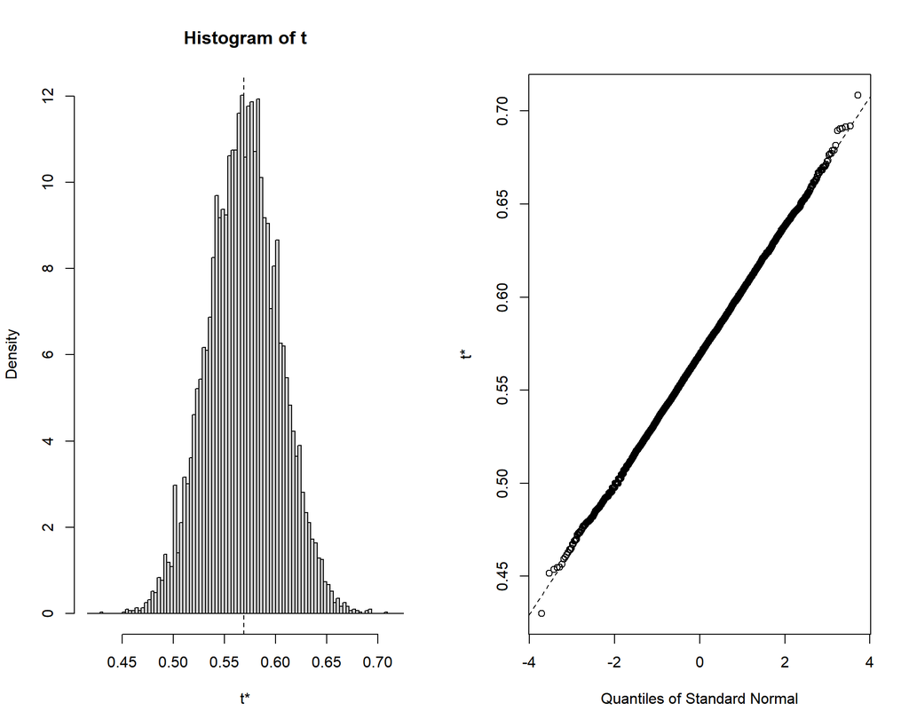

```
## BOOTSTRAP CONFIDENCE INTERVAL CALCULATIONS
## Based on 10000 bootstrap replicates
##
## CALL :
## boot.ci(boot.out = bootcorr, type = c("norm", "basic", "perc",
##     "bca"))
##
## Intervals :
## Level      Normal              Basic
## 95%   ( 0.5005,  0.6366 )   ( 0.5004,  0.6373 )
##
## Level     Percentile            BCa
## 95%   ( 0.5000,  0.6368 )   ( 0.5000,  0.6364 )
## Calculations and Intervals on Original Scale
```

## 13.2 Bootstrap of the percentage of Metabolism cells

Summary of the bootstrap resamples:

|  | R | original | bootBias | bootSE | bootMed |
| --- | --- | --- | --- | --- | --- |
| 1 | 10000 | 0.4166667 | -8.352118e-05 | 0.03457186 | 0.4166667 |

The variance of the percentage of Metabolism cells in the bootstrap resamples is 0.0011952.

The confidence interval of the percentage of Metabolism cells in the bootstrap resamples is presented as follows.

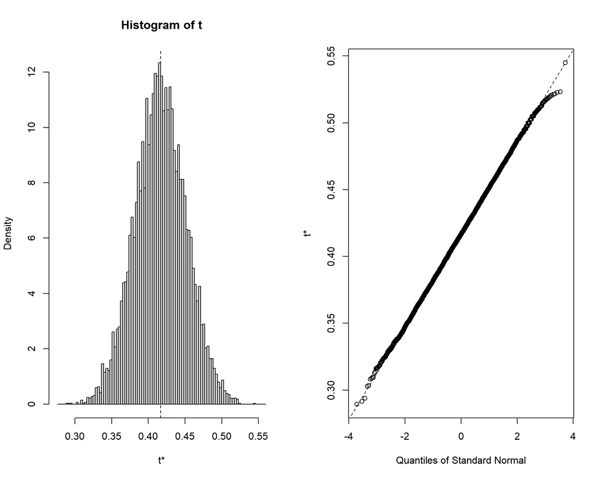

```
## BOOTSTRAP CONFIDENCE INTERVAL CALCULATIONS
## Based on 10000 bootstrap replicates
##
## CALL :
## boot.ci(boot.out = bootcorr, type = c("norm", "basic", "perc",
##     "bca"))
##
## Intervals :
## Level      Normal              Basic
## 95%   ( 0.3490,  0.4845 )   ( 0.3483,  0.4848 )
##
## Level     Percentile            BCa
## 95%   ( 0.3485,  0.4850 )   ( 0.3488,  0.4851 )
## Calculations and Intervals on Original Scale
```

## 13.3 Bootstrap of the percentage of Inflammation cells

Summary of the bootstrap resamples:

|  | R | original | bootBias | bootSE | bootMed |
| --- | --- | --- | --- | --- | --- |
| 1 | 10000 | 0.01470588 | 3.395038e-05 | 0.008509076 | 0.01435407 |

The variance of the percentage of Inflammation cells in the bootstrap resamples is 7.240438210^{-5}.

The confidence interval of the percentage of Inflammation cells in the bootstrap resamples is presented as follows.

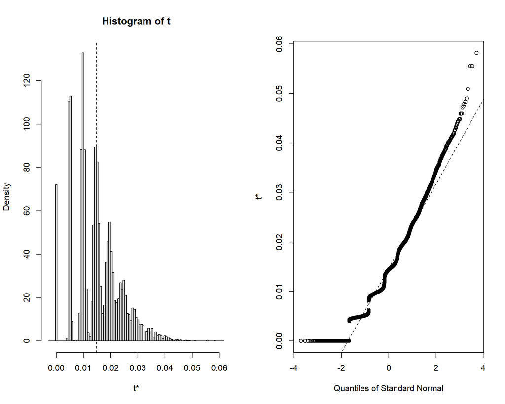

```
## BOOTSTRAP CONFIDENCE INTERVAL CALCULATIONS
## Based on 10000 bootstrap replicates
##
## CALL :
## boot.ci(boot.out = bootcorr, type = c("norm", "basic", "perc",
##     "bca"))
##
## Intervals :
## Level      Normal              Basic
## 95%   (-0.0020,  0.0313 )   (-0.0044,  0.0294 )
##
## Level     Percentile            BCa
## 95%   ( 0.0000,  0.0338 )   ( 0.0046,  0.0404 )
## Calculations and Intervals on Original Scale
```

# 14 Cell subtype percentages of PLX5622 07d

## 14.1 Bootstrap of the percentage of Transporter cells

Summary of the bootstrap resamples:

|  | R | original | bootBias | bootSE | bootMed |
| --- | --- | --- | --- | --- | --- |
| 1 | 10000 | 0.7179487 | -0.0004145242 | 0.07238776 | 0.72 |

The variance of the percentage of Transporter cells in the bootstrap resamples is 0.00524.

The confidence interval of the percentage of Transporter cells in the bootstrap resamples is presented as follows.

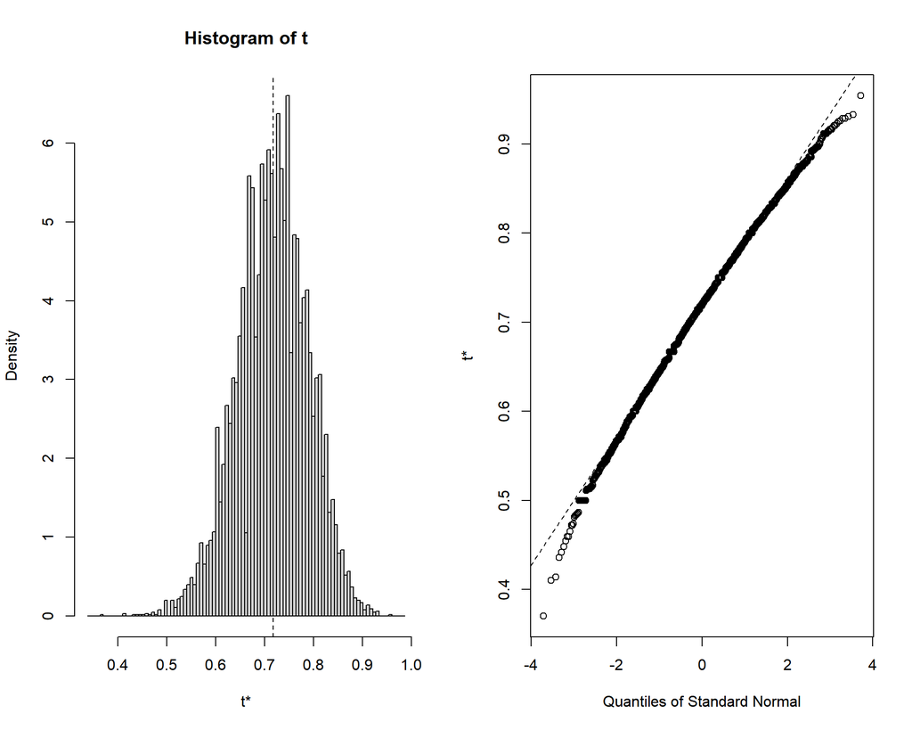

```
## BOOTSTRAP CONFIDENCE INTERVAL CALCULATIONS
## Based on 10000 bootstrap replicates
##
## CALL :
## boot.ci(boot.out = bootcorr, type = c("norm", "basic", "perc",
##     "bca"))
##
## Intervals :
## Level      Normal              Basic
## 95%   ( 0.5765,  0.8602 )   ( 0.5848,  0.8677 )
##
## Level     Percentile            BCa
## 95%   ( 0.5682,  0.8511 )   ( 0.5526,  0.8409 )
## Calculations and Intervals on Original Scale
```

## 14.2 Bootstrap of the percentage of Metabolism cells

Summary of the bootstrap resamples:

|  | R | original | bootBias | bootSE | bootMed |
| --- | --- | --- | --- | --- | --- |
| 1 | 10000 | 0.2051282 | 0.0004584156 | 0.06504887 | 0.2045455 |

The variance of the percentage of Metabolism cells in the bootstrap resamples is 0.0042314.

The confidence interval of the percentage of Metabolism cells in the bootstrap resamples is presented as follows.

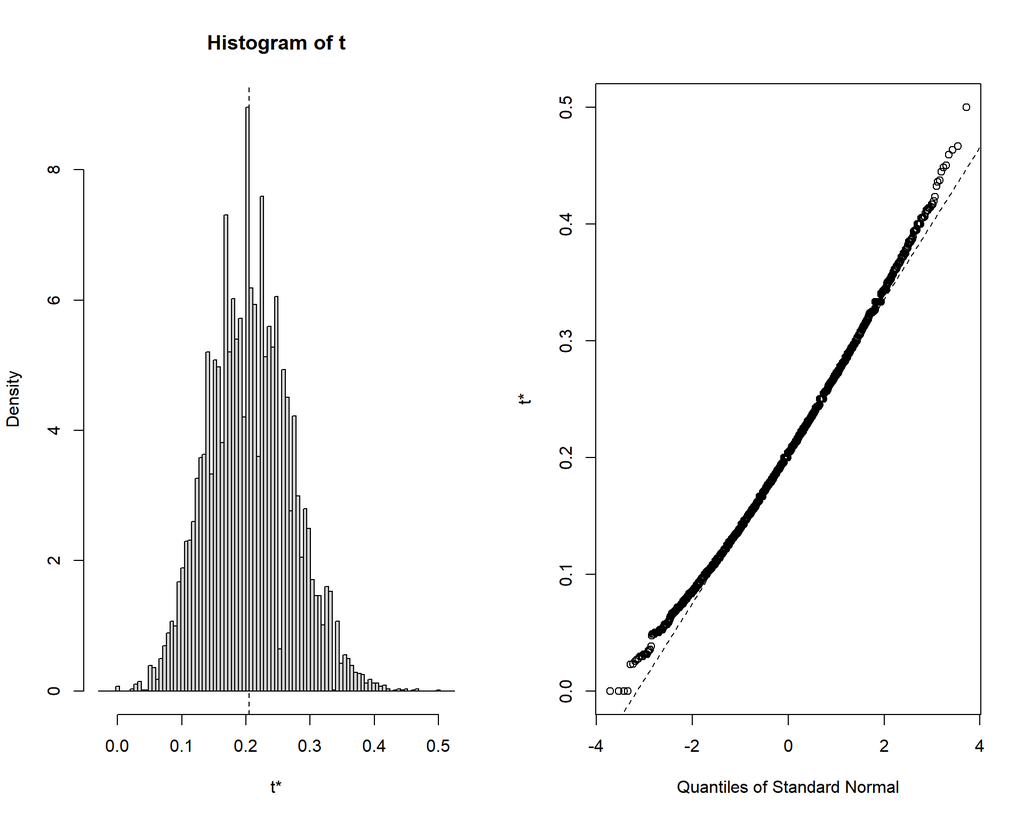

```
## BOOTSTRAP CONFIDENCE INTERVAL CALCULATIONS
## Based on 10000 bootstrap replicates
##
## CALL :
## boot.ci(boot.out = bootcorr, type = c("norm", "basic", "perc",
##     "bca"))
##
## Intervals :
## Level      Normal              Basic
## 95%   ( 0.0772,  0.3322 )   ( 0.0688,  0.3233 )
##
## Level     Percentile            BCa
## 95%   ( 0.0870,  0.3415 )   ( 0.0968,  0.3544 )
## Calculations and Intervals on Original Scale
```

## 14.3 Bootstrap of the percentage of Inflammation cells

Summary of the bootstrap resamples:

|  | R | original | bootBias | bootSE | bootMed |
| --- | --- | --- | --- | --- | --- |
| 1 | 10000 | 0.07692308 | -4.389141e-05 | 0.04233312 | 0.07317073 |

The variance of the percentage of Inflammation cells in the bootstrap resamples is 0.0017921.

The confidence interval of the percentage of Inflammation cells in the bootstrap resamples is presented as follows.

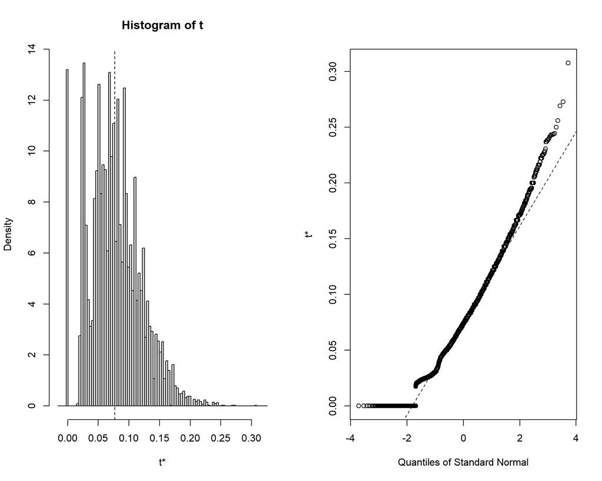

```
## BOOTSTRAP CONFIDENCE INTERVAL CALCULATIONS
## Based on 10000 bootstrap replicates
##
## CALL :
## boot.ci(boot.out = bootcorr, type = c("norm", "basic", "perc",
##     "bca"))
##
## Intervals :
## Level      Normal              Basic
## 95%   (-0.0060,  0.1599 )   (-0.0169,  0.1538 )
##
## Level     Percentile            BCa
## 95%   ( 0.0000,  0.1707 )   ( 0.0217,  0.2000 )
## Calculations and Intervals on Original Scale
```

# 15 Cell subtype percentages of PLX5622 28d

## 15.1 Bootstrap of the percentage of Transporter cells

Summary of the bootstrap resamples:

|  | R | original | bootBias | bootSE | bootMed |
| --- | --- | --- | --- | --- | --- |
| 1 | 10000 | 0.8317757 | -0.0002246583 | 0.03654173 | 0.8333333 |

The variance of the percentage of Transporter cells in the bootstrap resamples is 0.0013353.

The confidence interval of the percentage of Transporter cells in the bootstrap resamples is presented as follows.

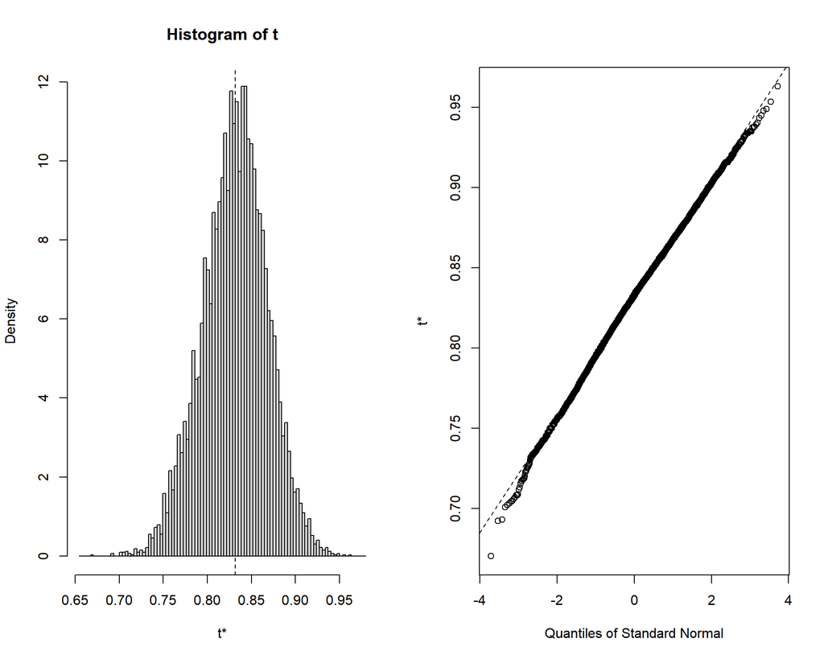

```
## BOOTSTRAP CONFIDENCE INTERVAL CALCULATIONS
## Based on 10000 bootstrap replicates
##
## CALL :
## boot.ci(boot.out = bootcorr, type = c("norm", "basic", "perc",
##     "bca"))
##
## Intervals :
## Level      Normal              Basic
## 95%   ( 0.7604,  0.9036 )   ( 0.7626,  0.9063 )
##
## Level     Percentile            BCa
## 95%   ( 0.7573,  0.9010 )   ( 0.7500,  0.8947 )
## Calculations and Intervals on Original Scale
```

## 15.2 Bootstrap of the percentage of Metabolism cells

Summary of the bootstrap resamples:

|  | R | original | bootBias | bootSE | bootMed |
| --- | --- | --- | --- | --- | --- |
| 1 | 10000 | 0.1401869 | 0.0002471073 | 0.03410851 | 0.1391304 |

The variance of the percentage of Metabolism cells in the bootstrap resamples is 0.0011634.

The confidence interval of the percentage of Metabolism cells in the bootstrap resamples is presented as follows.

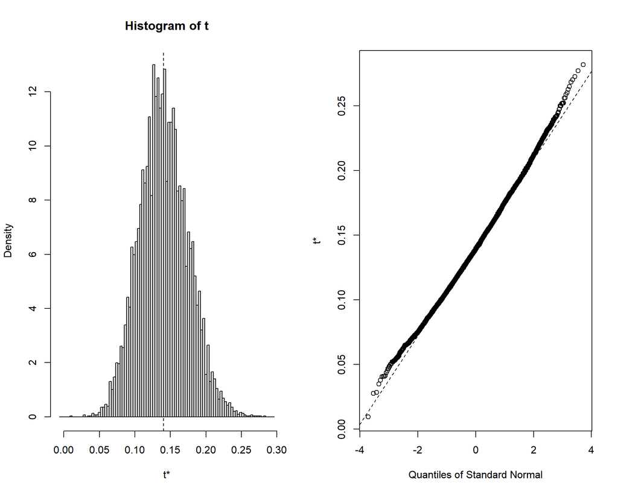

```
## BOOTSTRAP CONFIDENCE INTERVAL CALCULATIONS
## Based on 10000 bootstrap replicates
##
## CALL :
## boot.ci(boot.out = bootcorr, type = c("norm", "basic", "perc",
##     "bca"))
##
## Intervals :
## Level      Normal              Basic
## 95%   ( 0.0731,  0.2068 )   ( 0.0704,  0.2042 )
##
## Level     Percentile            BCa
## 95%   ( 0.0762,  0.2100 )   ( 0.0811,  0.2174 )
## Calculations and Intervals on Original Scale
```

## 15.3 Bootstrap of the percentage of Inflammation cells

Summary of the bootstrap resamples:

|  | R | original | bootBias | bootSE | bootMed |
| --- | --- | --- | --- | --- | --- |
| 1 | 10000 | 0.02803738 | -2.244902e-05 | 0.01607177 | 0.02702703 |

The variance of the percentage of Inflammation cells in the bootstrap resamples is 2.583019110^{-4}.

The confidence interval of the percentage of Inflammation cells in the bootstrap resamples is presented as follows.

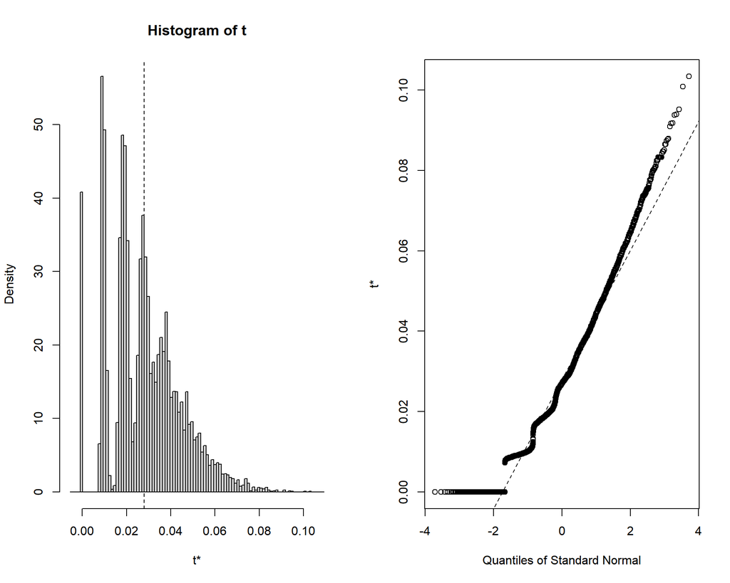

```
## BOOTSTRAP CONFIDENCE INTERVAL CALCULATIONS
## Based on 10000 bootstrap replicates
##
## CALL :
## boot.ci(boot.out = bootcorr, type = c("norm", "basic", "perc",
##     "bca"))
##
## Intervals :
## Level      Normal              Basic
## 95%   (-0.0034,  0.0596 )   (-0.0076,  0.0561 )
##
## Level     Percentile            BCa
## 95%   ( 0.0000,  0.0636 )   ( 0.0085,  0.0777 )
## Calculations and Intervals on Original Scale
```